# GLOBIOr: Example case study

Selwyn Hoeks, Floris K. Neijnens, Jelle P. Hilbers, Koen J.J. Kuipers, Aafke M. Schipper

19/01/26

## Install the GLOBIOr package

First, the `GLOBIOr` package needs to be installed, which can be done with the following code.

```r
# install package Windows
# install.packages("GLOBIOr_0.2.5.142.zip", repos=NULL)

# install package MacOS
install.packages("GLOBIOr_0.2.5.142.tgz", repos=NULL)
```

## Load packages

After the package is installed, we can load it into R.

```r
# load packages
library(GLOBIOr)
## GLOBIOr version: 0.2.5.143
```

```r
library(rnaturalearth)
library(terra)
## terra 1.8.70
 r
library(sf)
## Linking to GEOS 3.13.0, GDAL 3.8.5, PROJ 9.5.1; sf_use_s2() is TRUE
```

## Load the example MSA data

Next, we can use the built-in example data to fit MSA response relationships. For this example, we will use empirical data on the response of MSA to road disturbance, climate change, and land use. Note that example response data for nitrogen deposition, hunting and habitat fragmentation are also available from GLOBIO4 (Schipper et al., 2020), but won’t be used in this example.

For this example, we will only fit MSA responses for vertebrates, so after loading the data, we need to subset the data to include only vertebrates.

| GLOBIOr reference | GLOBIO pressure description | Unit |
| --- | --- | --- |
| dataMSA_RD | Distance to roads | km (log10) |
| dataMSA_LU | Land use | categorical |
| dataMSA_CC | Global mean temperature increase (GMTI) | degree Celsius |
| dataMSA_FR | Habitat fragmentation (patch area) | ha (log10) |
| dataMSA_HU | Hunting (distance to hunter access points) | km (log10) |
| dataMSA_ND | Atmospheric nitrogen deposition | kg/ha/year |

```r
# load example data, included in package for now
data(dataMSA_RD) # MSA response to roads
data(dataMSA_LU) #  MSA response to land use
data(dataMSA_CC) # MSA response to climate change

# request metadata for dataset included in GLOBOr
?dataMSA_RD
## No documentation for 'dataMSA_RD' in specified packages and libraries:
## you could try '??dataMSA_RD'
 r
# subset data
dataMSA_RD <- subset(dataMSA_RD, taxon=="vertebrates")
dataMSA_LU <- subset(dataMSA_LU, taxon=="vertebrates")
dataMSA_CC <- subset(dataMSA_CC, taxon=="vertebrates")

# explore one of the datasets
head(dataMSA_RD)
```

```
##                  study dataset RoadDist       MSA     MSA_t n_species
## 1  Delgado et al. 2004       5       10 0.9285714 0.9264706         8
## 2  Meunier et al. 2000     14a       50 1.0000000 0.9975490         3
## 3  Meunier et al. 2000     14b       50 1.0000000 0.9975490         3
## 4       Xu et al. 2013      33       25 1.0000000 0.9975490         1
## 5       Xu et al. 2013      33       75 1.0000000 0.9975490         1
## 6 Whitaker et al. 1997      29       10 0.8227023 0.8211204        27
##   RoadDistLog10       taxon
## 1      1.000000 vertebrates
## 2      1.698970 vertebrates
## 3      1.698970 vertebrates
## 4      1.397940 vertebrates
## 5      1.875061 vertebrates
## 6      1.000000 vertebrates
```

## Fit MSA Relationship(s)

We can now fit MSA response relationships using the `fitMSAModels()` function (see example below). This function fits MSA relationship(s) for a given dataset and returns a list of fitted models. By default, the `fitMSAModels()` function tries to fit six models:

1. `defaultBeta`: a default beta model without any transformation of the response variable.
2. `svBeta`: a beta model with a Smithson-Verkuilen transformation of the input data, so the response variable is restricted to the open interval (0,1).
3. `ordBeta`: an ordered beta model capable of modeling potential zeros and ones in the response variable.
4. `zeroInfBeta`: a zero-inflated beta model is a two-part model that combines a binomial submodel for the probability of structural zeros with a beta regression for outcomes in the open interval (0,1).
5. `oneInfBeta`: a one-inflated beta model is a two-part model that combines a binomial submodel for the probability of structural ones with a beta regression for outcomes in the open interval (0,1).
6. `zeroOneInfBeta`: a zero–one inflated beta model is a three-part (mixture) model that combines a multinomial submodels for the probabilities of exact zeros and ones with a beta regression for outcomes in the open interval (0,1).

The `fitMSAModels()` function has two required input arguments:

1. `beta`: a model formula
2. `data`: the MSA input dataset

Besides these the `fitMSAModels()` function several optional arguments, which allow for the specification of the submodels: zero-inflated, one-inflated or zero-one inflated submodel (see the `zi`, `oi` and `zoi` input arguments, respectively). By default, the `fitMSAModels()` function reuses the required beta formula (`beta`) to fit all specified submodels. For more information, see the documentation of the `fitMSAModels()` function (`?fitMSAModels`). Additionally, the `tryModels` input argument can be used to specify which models should be fitted (i.e. specific models can be excluded). The `weights` input argument can be used to specify the weights of the data points (by default no weights are used). The function also provides response plots of the fitted models, as a default the `plot` input argument is set to `TRUE`.

Below, we fit the MSA relationship for the road dataset. Here, MSA is modeled as a function of the distance to the nearest road (log10 transformed because of the skewed data distribution). The original source dataset, nested within the study, is used as a random effect (Schipper et al., 2020). The weights are set to the square root of the number of species in the dataset. Because only one formula is specified (`beta`), all submodels will be using the identical formula.

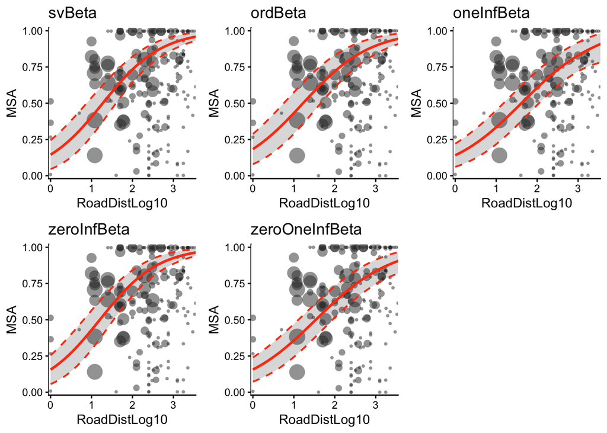

```r
# fit potential MSA models for the road dataset
modelsMSA_RD <- fitMSAModels(beta= MSA ~ RoadDistLog10 + (1 | study / dataset),
                            data = dataMSA_RD,
                            weights = sqrt(n_species),
                            plot=TRUE)

## Zeros and ones detected in response.
##
## Fitting models...
## - defaultBeta model cannot be fitted, zeros and/or ones in response data.
## - fitting svBeta model.
## - fitting ordBeta model.
## - Fitting zeroInfBeta model. Ones detected, using sv transformation on ones.
## - Fitting oneInfBeta model. Zeros detected, using sv transformation on zeros.
## - Fitting zeroOneInfBeta model.
##
## Creating response plots for predictor: RoadDistLog10
```

As can be seen from the outputs and plot generated by the `fitMSAModels()` function, five models are fitted to the relationship between MSA and the log10 of road distance. The selection of models that can be fitted depends on the nature of the data. In this case, the dataset includes both zeros and ones in addition to values between zero and one. Therefore, it is not possible to fit the `defaultBeta`, while the other five models can be applied.

Next, we apply the `fitMSAModels()` function to estimate MSA in relation to land use:

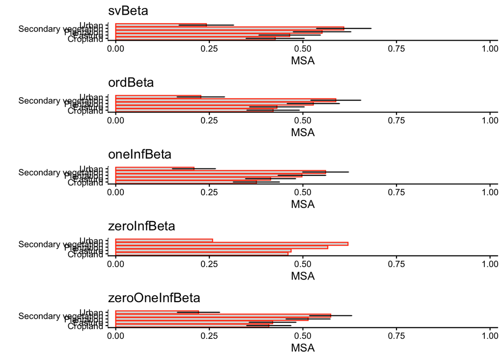

```r
# fit potential MSA models for the land use dataset
modelsMSA_LU <- fitMSAModels(MSA ~ land_use + (1 | study / dataset),
                         data = dataMSA_LU,
                         weights = sqrt(n_species),
                         plot = TRUE)

## Zeros and ones detected in response.
##
## Fitting models...
## - defaultBeta model cannot be fitted, zeros and/or ones in response data.
## - fitting svBeta model.
## - fitting ordBeta model.
## - Fitting zeroInfBeta model. Ones detected, using sv transformation on ones.
## - Fitting oneInfBeta model. Zeros detected, using sv transformation on zeros.
## - Fitting zeroOneInfBeta model.
##
## Creating response plots for predictor: land_use
```

In the final example of this case study, we fit models to investigate the relationship between MSA and climate change (as represented by the global mean temperature increase). In this case, the dataset includes only values between zero and one. Therefore, only the defaultBeta and ordBeta are used; all other models are omitted.

```r
# fit potential MSA models for the climate change dataset
modelsMSA_CC <- fitMSAModels(MSA ~ GMTI + (1 | study),
                              data = dataMSA_CC,
                              dispformula = ~GMTI,
                              weights = sqrt(n_species),
                              plot = TRUE,
                              debug = TRUE)
```

```
## [1] "Inflation formulas: "
## [1] "- inf: ~"                  "- inf: MSA"
## [3] "- inf: GMTI + (1 | study)"
## [1] "- zi: ~"                  "- zi: MSA"
## [3] "- zi: GMTI + (1 | study)"
## [1] "- oi: ~"                  "- oi: MSA"
## [3] "- oi: GMTI + (1 | study)"
## [1] "- zoi: ~"                  "- zoi: MSA"
## [3] "- zoi: GMTI + (1 | study)"
## [1] "- coi: ~"                  "- coi: MSA"
## [3] "- coi: GMTI + (1 | study)"
## [1] "using weights"
## [1] "weights_col: sqrt(n_species)"
## [1] "weights_col: sqrt(n_species)"
## [1] "weights_col: sqrt(n_species)"
## [1] "weights_col: sqrt(n_species)"
## [1] "weights_col: sqrt(data$n_species)"
## [1] "weights_col: sqrt(data$n_species)"
```

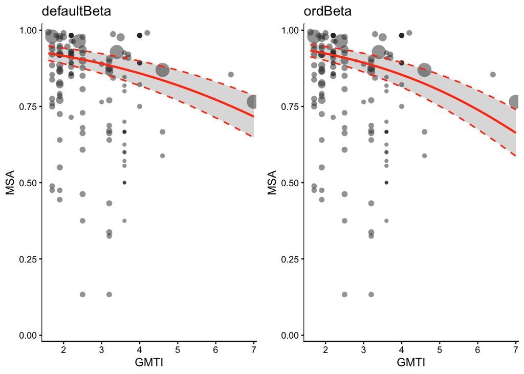

```r
## No zeros and/or ones detected in response.
##
## Fitting models...
## - fitting defaultBeta model.
## - svBeta model not fitted: no zeros or ones in response data.
## - fitting ordBeta model.
## - zeroInfBeta not fitted: no zeros in the response data.
## - oneInfBeta not fitted: no ones in the response data.
## - zeroOneInfBeta not fitted: needs both ones and zeros in the response data.
##
## Creating response plots for predictor: GMTI
## [1] "defaultBeta plot"
## [1] "ordBeta plot"
```

## Select the most appropriate model

To select the most appropriate model from the fitted options provided by the `fitMSAModels()` function, the individual models can be evaluated using the `testMSAModel()` function. This function aims to determine the most appropriate model based on the `DHARMa` diagnostics (dispersion test) and a measure for goodness of fit; the root mean square error (RMSE). The `testMSAModel()` function does the following:

1. First, it checks for dispersion issues using the `DHARMa` package (Hartig, 2017). The p-value returned by the `DHARMa::testDispersion()` is used to evaluate the dispersion of provided models. By default 500 simulated residuals are used, the `nsim` argument can be set to a positive integer to increase or decrease the number of simulations (a minimum of 250 is recommended).
2. Next, `testMSAModel()` calculates the RMSE of the models. It provides two sets of RMSE values; one based on the models fitted to the entire dataset and one based on a blocked cross-validation approach. By default, five cross-validation folds are used. The n `cv` argument can be set to a positive integer to increase or decrease the number of folds. In the blocked cross-validation, the data is by default grouped by the first level in the random effect structure provided in the corresponding model. In this example, the random effect is `(1|study/dataset)`, thus the `study` column will be used to group the data. The variable used for grouping the data in the blocked cross-validation approach can be set manually via the `groupcv` input argument.

The function will return a `data.frame` that contains the diagnostics for each model. Finally, one model will be suggested as the most appropriate model based on the diagnostics (a model without dispersion issues and the lowest cross-validated RMSE). Of course this suggestion still requires to be checked carefully, and any other model can be selected to continue (or other models can be fitted to acquire an suitable model).

```r
# check for dispersion issues and cross-validated RSME
statsMSA_RD = testMSAModels(models=modelsMSA_RD)

## Diagnostics
## Running DHARMa dispersion tests.
## Dispersion issues found for: svBeta, zeroInfBeta
## +-------------+----------------+------------------+
## |   ModelName | DispersionPval | DispersionIssues |
## +-------------+----------------+------------------+
## |      svBeta |          0.012 |             TRUE |
## | zeroInfBeta |          0.028 |             TRUE |
## +-------------+----------------+------------------+
##
## Model performance based on RMSE (full dataset).
## +----------------+------------------+-------+
## |      ModelName | DispersionIssues |  RMSE |
## +----------------+------------------+-------+
## | zeroOneInfBeta |            FALSE | 0.159 |
## |     oneInfBeta |            FALSE | 0.168 |
## |    zeroInfBeta |             TRUE | 0.180 |
## |         svBeta |             TRUE | 0.185 |
## |        ordBeta |            FALSE | 0.194 |
## +----------------+------------------+-------+
##
## Calculating RMSE using blocked cross-validation.
## Progress: [                              ]   0% | ETA: ...Progress: [------                        ]  20% | ETA: 0.0 (sec)Progress: [------------                  ]  40% | ETA: 0.7 (sec)Progress: [------------------            ]  60% | ETA: 0.7 (sec)Progress: [------------------------      ]  80% | ETA: 0.4 (sec)Progress: [------------------------------] 100% | ETA: 0.0 (sec)
## +----------------+------------------+---------+
## |      ModelName | DispersionIssues | RMSE_CV |
## +----------------+------------------+---------+
## | zeroOneInfBeta |            FALSE |   0.292 |
## |     oneInfBeta |            FALSE |   0.293 |
## |        ordBeta |            FALSE |   0.307 |
## |         svBeta |             TRUE |   0.315 |
## |    zeroInfBeta |             TRUE |   0.320 |
## +----------------+------------------+---------+
```

```r
# check for dispersion issues and cross-validated RSME
statsMSA_LU = testMSAModels(models=modelsMSA_LU)

## Diagnostics
## Running DHARMa dispersion tests.
## No dispersion issues found.
##
## Model performance based on RMSE (full dataset).
## +----------------+------------------+-------+
## |      ModelName | DispersionIssues |  RMSE |
## +----------------+------------------+-------+
## | zeroOneInfBeta |            FALSE | 0.089 |
## |     oneInfBeta |            FALSE | 0.092 |
## |    zeroInfBeta |            FALSE | 0.102 |
## |         svBeta |            FALSE | 0.104 |
## |        ordBeta |            FALSE | 0.111 |
## +----------------+------------------+-------+
##
## Calculating RMSE using blocked cross-validation.
## Progress: [                              ]   0% | ETA: ...Progress: [------                        ]  20% | ETA: 0.0 (sec)Progress: [------------                  ]  40% | ETA: 0.7 (sec)Progress: [------------------            ]  60% | ETA: 0.7 (sec)Progress: [------------------------      ]  80% | ETA: 0.5 (sec)Progress: [------------------------------] 100% | ETA: 0.0 (sec)
## +----------------+------------------+---------+
## |      ModelName | DispersionIssues | RMSE_CV |
## +----------------+------------------+---------+
## | zeroOneInfBeta |            FALSE |   0.202 |
## |        ordBeta |            FALSE |   0.233 |
## |     oneInfBeta |            FALSE |   0.233 |
## |         svBeta |            FALSE |   0.234 |
## |    zeroInfBeta |            FALSE |   0.235 |
## +----------------+------------------+---------+
```

```r
# check for dispersion issues and cross-validated RSME
statsMSA_CC = testMSAModels(models=modelsMSA_CC)

## Diagnostics
## Running DHARMa dispersion tests.
## Dispersion issues found for: defaultBeta, ordBeta
## +-------------+----------------+------------------+
## |   ModelName | DispersionPval | DispersionIssues |
## +-------------+----------------+------------------+
## | defaultBeta |          0.012 |             TRUE |
## |     ordBeta |          0.016 |             TRUE |
## +-------------+----------------+------------------+
## All models fitted have dispersion issues.
## Model with smallest dispersion issue: ordBeta.
##
## Model performance based on RMSE (full dataset).
## +-------------+------------------+-------+
## |   ModelName | DispersionIssues |  RMSE |
## +-------------+------------------+-------+
## | defaultBeta |             TRUE | 0.133 |
## |     ordBeta |             TRUE | 0.134 |
## +-------------+------------------+-------+
##
## Calculating RMSE using blocked cross-validation.
## Progress: [                              ]   0% | ETA: ...Progress: [---------------               ]  50% | ETA: 0.0 (sec)Progress: [------------------------------] 100% | ETA: 0.0 (sec)
## +-------------+------------------+---------+
## |   ModelName | DispersionIssues | RMSE_CV |
## +-------------+------------------+---------+
## |     ordBeta |             TRUE |   0.120 |
## | defaultBeta |             TRUE |   0.121 |
## +-------------+------------------+---------+
```

Now that we have reviewed the model diagnostics (the `data.frame` returned by `testMSAModels()`), we can extract the most appropriate models to continue our analysis. The `selectMSAModel()` function can be used for this purpose. There are three options to extract the model:

1. By model name, using the names as written in the `ModelName` column of the `data.frame` returned by the `testMSAModels()` function.
2. By index, using the row index of the `data.frame` returned by the `testMSAModels()` function.
3. By providing the `data.frame` returned by the previous `testMSAModels()` call directly to the `selectMSAModel` function. This will use the `SuggestedModel` column to extract the model.

The code below shows an example of all three options.

```r
#--- select model, different options are available
selectedModelMSA_RD = selectMSAModel(models=modelsMSA_RD,
                                     select="zeroOneInfBeta")
## Selecting model by name: zeroOneInfBeta.
 r
selectedModelMSA_LU = selectMSAModel(models=modelsMSA_LU,
                                     select=5)
## Selecting model by index, selected model: oneInfBeta.
 r
selectedModelMSA_CC = selectMSAModel(models=modelsMSA_CC,
                                     select=statsMSA_CC)
```

Next, the MSA response can be plotted by providing the returned model object to the `plotMSAResponse()` function. Below two examples are provided. For additional plotting options see the R help file: `?plotMSAResponse`

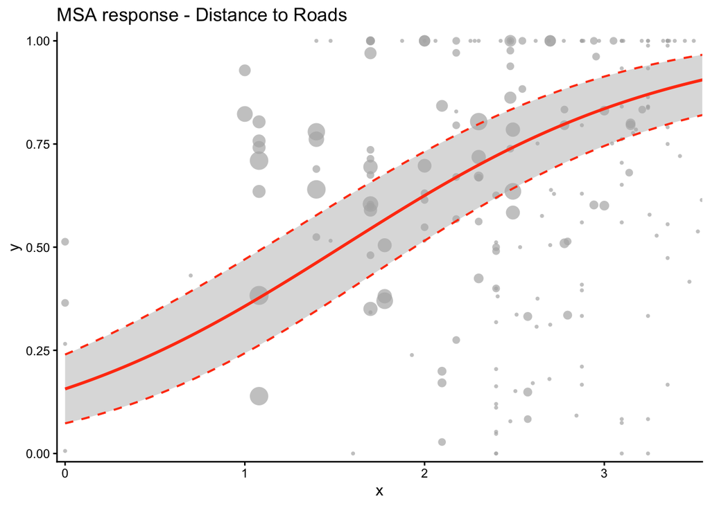

```r
# plot final response of the selected model
plotMSAResponse(model = selectedModelMSA_RD,
                predCol = RoadDistLog10,
                main="MSA response - Distance to Roads")
```

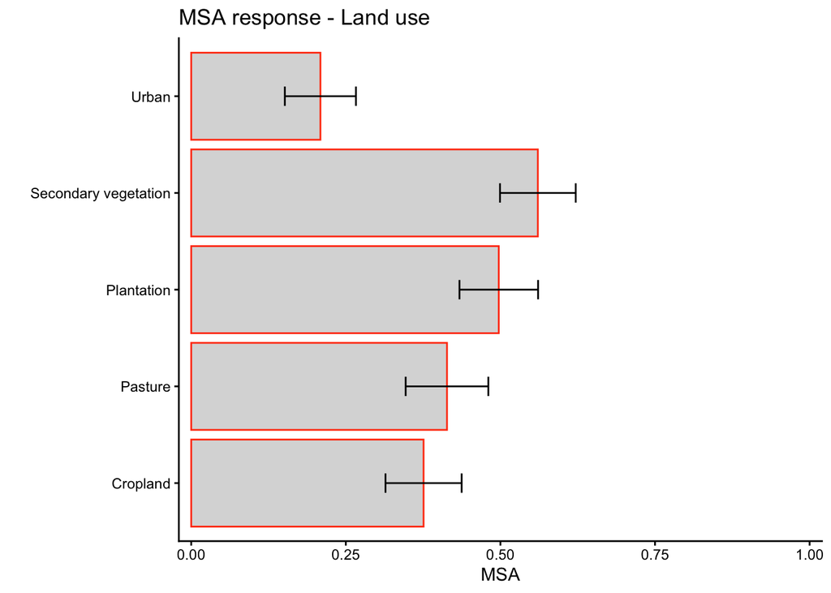

```r
# plot final response of the selected model
plotMSAResponse(model = selectedModelMSA_LU,
                predCol = land_use,
                datacolor = "#333333",
                fitcolor="#ff4010",
                xlab="",
                ylab="MSA",
                main="MSA response - Land use")
```

## Spatial pressure maps

Before being able to predict the MSA spatially, we require pressure maps. The can vary depending on the scenario of interest (e.g. current or future conditions). For this case study, multiple pressure maps were prepared for Europe on the default 300m by 300m resolution. This example includes maps for 2015 and for a future scenario (2050 SSP3). These example maps can be downloaded from `Figshare` using the `GLOBIOr` function called `downloadExampleMaps()`, see code below (total size: `~720mb`). The `downloadExampleMaps()` function requires a path (`downloadDir`) to store the maps (`tif` files). This path can be relative (inside the current working directory) or absolute. The function will not redownload the maps if they are found in the provided `downloadDir`. By default the `downloadExampleMaps()` function will load the maps into a single `list` object.

```r
# download example pressure maps from Figshare
maps = downloadExampleMaps(downloadDir = "maps")
```

```r
# see what is inside the loaded data
str(maps,1)
```

```
## List of 10
##  $ tifpaths               :'data.frame': 9 obs. of  6 variables:
##  $ climatechange_2015     :S4 class 'SpatRaster' [package "terra"]
##  $ climatechange_2050_SSP3:S4 class 'SpatRaster' [package "terra"]
##  $ landuse_2015           :S4 class 'SpatRaster' [package "terra"]
##  $ landuse_2050_SSP3      :S4 class 'SpatRaster' [package "terra"]
##  $ landuse_conv_table     :'data.frame': 8 obs. of  2 variables:
##  $ roaddistkm_2015_log10  :S4 class 'SpatRaster' [package "terra"]
##  $ roaddistkm_2050_log10  :S4 class 'SpatRaster' [package "terra"]
##  $ country_borders        :S4 class 'SpatRaster' [package "terra"]
##  $ region_borders         :S4 class 'SpatRaster' [package "terra"]
```

## Set pressure map levels

```r
# categorical values used in model training data
print(unique(dataMSA_LU$land_use))
```

```
## [1] "Cropland"             "Pasture"              "Plantation"
## [4] "Secondary vegetation" "Urban"
```

```r
 r
# conversion data.frame (provided in the example data)
print(maps$landuse_conv_table)
```

```
##   value               cover
## 1     1               Urban
## 2     2          Cropland_H
## 3     3           Pasture_H
## 4     4           Pasture_L
## 5     5          Plantation
## 6     6 SecondaryVegetation
## 7     7          Cropland_L
## 8     8             Natural
```

```r
# set levels landuse 2015
maps$landuse_2015 = setRasterLevels(maps$landuse_2015,
                                    NumericalValue=maps$landuse_conv_table$value,
                                    CoverName=maps$landuse_conv_table$cover)

# set levels landuse 2050 SSP3
maps$landuse_2050_SSP3 = setRasterLevels(maps$landuse_2050_SSP3,
                                         NumericalValue=maps$landuse_conv_table$value,
                                         CoverName=maps$landuse_conv_table$cover)
```

## Plot pressure maps

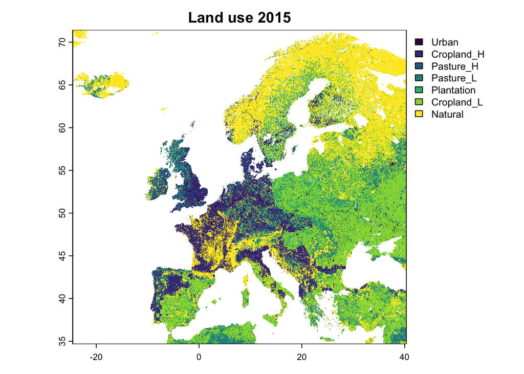

```r
# plot some of the example pressure maps (2015)
# using the default terra package plotting function (will be replaced later)
terra::plot(maps$landuse_2015,main="Land use 2015")
```

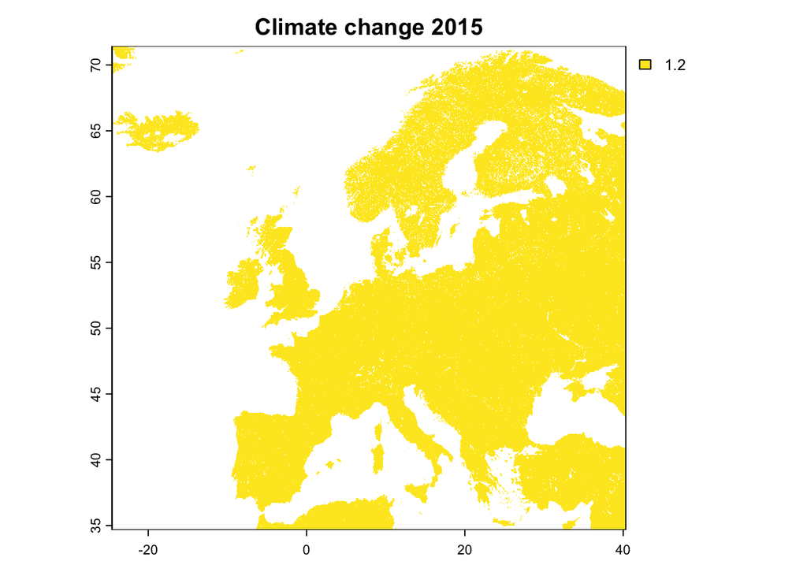

```r
terra::plot(maps$climatechange_2015,main="Climate change 2015")
```

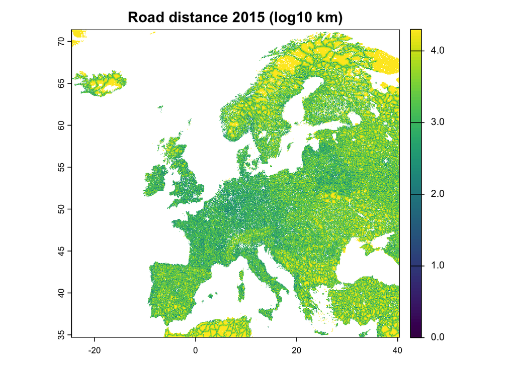

```r
terra::plot(maps$roaddistkm_2015_log10,main="Road distance 2015 (log10 km)")
```

## Predicting MSA spatially

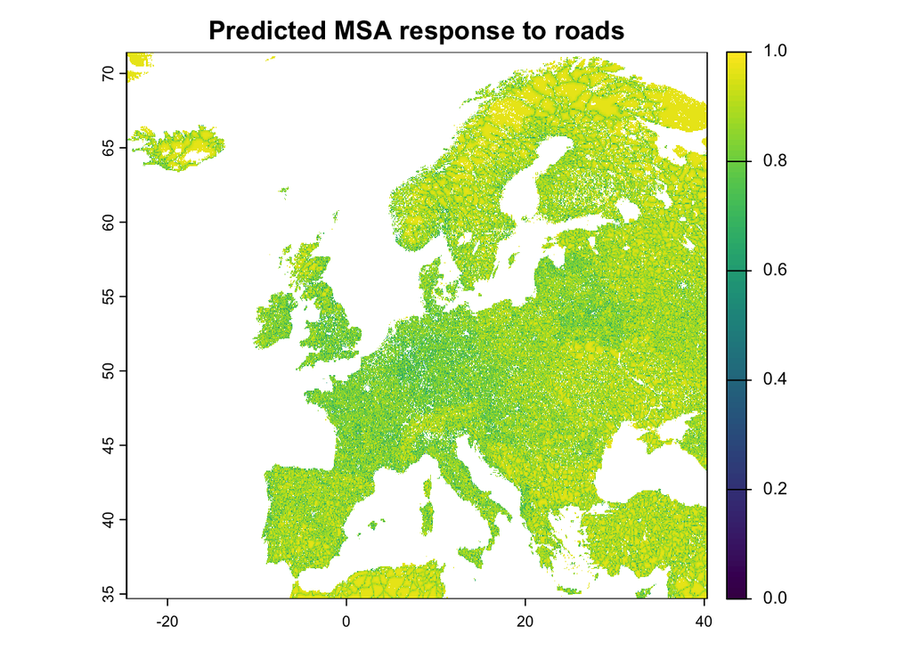

```r
tictoc::tic()
predictedMSA_RD = predictMSAPressure(model = selectedModelMSA_RD,
                                     variableName = "RoadDistLog10",
                                     pressureMap = maps$roaddistkm_2015_log10,
                                     predictionMask = list(maps$landuse_2015),
                                     maskPredictionFor = list(c("Urban")))
## Masking prediction for Urban in mask 1
## Progress: [                              ]   0% | ETA: ...Progress: [-                             ]   6% | ETA: 9.1 (sec)Progress: [---                           ]  12% | ETA: 12.3 (sec)Progress: [-----                         ]  18% | ETA: 11.3 (sec)Progress: [-------                       ]  24% | ETA: 11.6 (sec)Progress: [--------                      ]  29% | ETA: 11.2 (sec)Progress: [----------                    ]  35% | ETA: 10.5 (sec)Progress: [------------                  ]  41% | ETA: 9.8 (sec)Progress: [--------------                ]  47% | ETA: 9.0 (sec)Progress: [---------------               ]  53% | ETA: 8.3 (sec)Progress: [-----------------             ]  59% | ETA: 7.4 (sec)Progress: [-------------------           ]  65% | ETA: 6.4 (sec)Progress: [---------------------         ]  71% | ETA: 5.4 (sec)Progress: [----------------------        ]  76% | ETA: 4.4 (sec)Progress: [------------------------      ]  82% | ETA: 3.3 (sec)Progress: [--------------------------    ]  88% | ETA: 2.2 (sec)Progress: [----------------------------  ]  94% | ETA: 1.1 (sec)Progress: [------------------------------] 100% | ETA: 0.0 (sec)
## Predicting MSA pressure for RoadDistLog10 using model zeroOneInfBeta
## Progress: [                              ]   0% | ETA: ...Progress: [-                             ]   6% | ETA: 3.5 (sec)Progress: [---                           ]  12% | ETA: 6.5 (sec)Progress: [-----                         ]  19% | ETA: 7.4 (sec)Progress: [-------                       ]  25% | ETA: 8.3 (sec)Progress: [---------                     ]  31% | ETA: 7.9 (sec)Progress: [-----------                   ]  38% | ETA: 7.4 (sec)Progress: [-------------                 ]  44% | ETA: 6.9 (sec)Progress: [---------------               ]  50% | ETA: 6.6 (sec)Progress: [----------------              ]  56% | ETA: 5.9 (sec)Progress: [------------------            ]  62% | ETA: 5.2 (sec)Progress: [--------------------          ]  69% | ETA: 4.4 (sec)Progress: [----------------------        ]  75% | ETA: 3.5 (sec)Progress: [------------------------      ]  81% | ETA: 2.7 (sec)Progress: [--------------------------    ]  88% | ETA: 1.8 (sec)Progress: [----------------------------  ]  94% | ETA: 0.9 (sec)Progress: [------------------------------] 100% | ETA: 0.0 (sec)
 r
tictoc::toc()
## 35.119 sec elapsed
 r
# plot predicted MSA map
plot(predictedMSA_RD,main="Predicted MSA response to roads",type = 'continuous', range = c(0, 1))
```

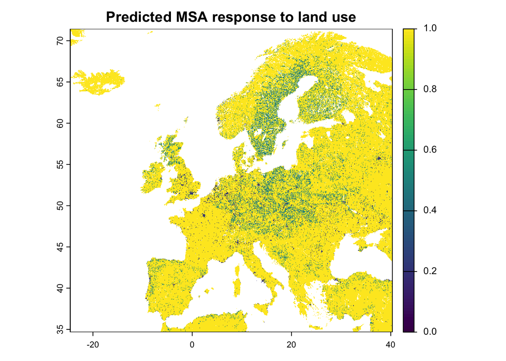

```r
tictoc::tic()
predictedMSA_RD2 = predictMSAPressure(model = selectedModelMSA_RD,
                                      variableName = "RoadDistLog10",
                                      pressureMap = maps$roaddistkm_2015_log10,
                                      predictionMask = c(maps$landuse_2015,maps$region_borders),
                                      maskPredictionFor = list(c("Urban"),c(1,3)))
## Masking prediction for Urban in mask 1
## Progress: [                              ]   0% | ETA: ...Progress: [-                             ]   6% | ETA: 3.5 (sec)Progress: [---                           ]  12% | ETA: 9.6 (sec)Progress: [-----                         ]  18% | ETA: 11.0 (sec)Progress: [-------                       ]  24% | ETA: 11.5 (sec)Progress: [--------                      ]  29% | ETA: 10.7 (sec)Progress: [----------                    ]  35% | ETA: 10.2 (sec)Progress: [------------                  ]  41% | ETA: 9.4 (sec)Progress: [--------------                ]  47% | ETA: 8.6 (sec)Progress: [---------------               ]  53% | ETA: 7.9 (sec)Progress: [-----------------             ]  59% | ETA: 7.1 (sec)Progress: [-------------------           ]  65% | ETA: 6.2 (sec)Progress: [---------------------         ]  71% | ETA: 5.2 (sec)Progress: [----------------------        ]  76% | ETA: 4.2 (sec)Progress: [------------------------      ]  82% | ETA: 3.2 (sec)Progress: [--------------------------    ]  88% | ETA: 2.1 (sec)Progress: [----------------------------  ]  94% | ETA: 1.1 (sec)Progress: [------------------------------] 100% | ETA: 0.0 (sec)
## Masking prediction for 1, 3 in mask 2
## Progress: [                              ]   0% | ETA: ...Progress: [-                             ]   6% | ETA: 3.9 (sec)Progress: [---                           ]  12% | ETA: 9.7 (sec)Progress: [-----                         ]  19% | ETA: 9.9 (sec)Progress: [-------                       ]  25% | ETA: 10.5 (sec)Progress: [---------                     ]  31% | ETA: 10.0 (sec)Progress: [-----------                   ]  38% | ETA: 9.3 (sec)Progress: [-------------                 ]  44% | ETA: 8.5 (sec)Progress: [---------------               ]  50% | ETA: 7.8 (sec)Progress: [----------------              ]  56% | ETA: 7.0 (sec)Progress: [------------------            ]  62% | ETA: 6.2 (sec)Progress: [--------------------          ]  69% | ETA: 5.2 (sec)Progress: [----------------------        ]  75% | ETA: 4.2 (sec)Progress: [------------------------      ]  81% | ETA: 3.1 (sec)Progress: [--------------------------    ]  88% | ETA: 2.1 (sec)Progress: [----------------------------  ]  94% | ETA: 1.0 (sec)Progress: [------------------------------] 100% | ETA: 0.0 (sec)
## Predicting MSA pressure for RoadDistLog10 using model zeroOneInfBeta
## Progress: [                              ]   0% | ETA: ...Progress: [-                             ]   6% | ETA: 3.3 (sec)Progress: [---                           ]  12% | ETA: 6.2 (sec)Progress: [-----                         ]  18% | ETA: 7.3 (sec)Progress: [-------                       ]  24% | ETA: 8.3 (sec)Progress: [--------                      ]  29% | ETA: 8.1 (sec)Progress: [----------                    ]  35% | ETA: 7.7 (sec)Progress: [------------                  ]  41% | ETA: 7.1 (sec)Progress: [--------------                ]  47% | ETA: 6.6 (sec)Progress: [---------------               ]  53% | ETA: 6.2 (sec)Progress: [-----------------             ]  59% | ETA: 5.6 (sec)Progress: [-------------------           ]  65% | ETA: 4.9 (sec)Progress: [---------------------         ]  71% | ETA: 4.1 (sec)Progress: [----------------------        ]  76% | ETA: 3.4 (sec)Progress: [------------------------      ]  82% | ETA: 2.5 (sec)Progress: [--------------------------    ]  88% | ETA: 1.7 (sec)Progress: [----------------------------  ]  94% | ETA: 0.8 (sec)Progress: [------------------------------] 100% | ETA: 0.0 (sec)
 r
tictoc::toc()
## 52.126 sec elapsed
 r
tictoc::tic()
predictedMSA_LU = predictMSAPressure(model = selectedModelMSA_LU,
                                         variableName = "land_use",
                                         pressureMap = maps$landuse_2015)
 r
tictoc::toc()
## 11.494 sec elapsed
 r
# plot predicted MSA map
plot(predictedMSA_LU,main="Predicted MSA response to land use",type = 'continuous', range = c(0, 1))
```

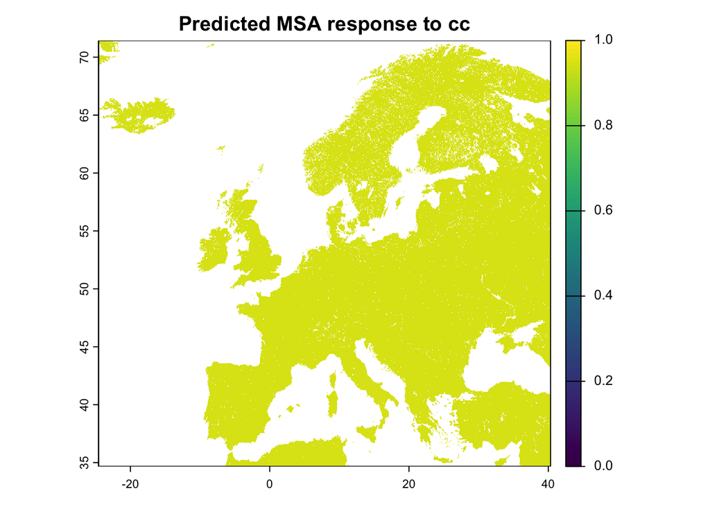

```r
tictoc::tic()
predictedMSA_CC = predictMSAPressure(model = selectedModelMSA_CC,
                                         variableName = "GMTI",
                                         pressureMap = maps$climatechange_2015)
 r
tictoc::toc()
## 9.153 sec elapsed
 r
# plot predicted MSA map
plot(predictedMSA_CC,main="Predicted MSA response to cc",type = 'continuous', range = c(0, 1))
```

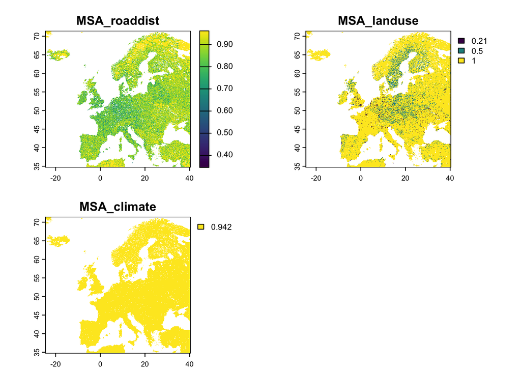

```r
# plot the individual MSA predictions
tmp = c(predictedMSA_RD,predictedMSA_LU,predictedMSA_CC)
names(tmp) = c("MSA_roaddist","MSA_landuse","MSA_climate")
terra::plot(tmp)
```